# ניתוח סקר מתמחים ברפואה

ניתוח מקיף של מאפייני התמחות ותוצאות עבור מתמחים

Hagay Ladany

דצמבר 27, 2025

## 1 סיכום מנהלים

דוח זה מציג ניתוח סטטיסטי מקיף המבוסס על נתוני סקר מתמחים, מסודר לפי שאלות המחקר. הניתוח כולל מדדי עומס, סיפוק, דמוגרפיה וקריירה עתידית. כל הגרפים כוללים את גודל המדגם (N) לכל קבוצה.

**סף מינימלי לכוח סטטיסטי:** N ≥ 7

## 2 1. דמוגרפיה ובחירת התמחות

### 2.1 גיל וקטגוריית התמחות

האם גיל המתמחה קשור לבחירת תחום ההתמחות (כירורגי/לא כירורגי)?

עמודות: דמוגרפיה: מהו גילך?; נתוני הכשרה: קטגורית התמחות

**מבחן סטטיסטי:** Chi-square **מסקנה:** לא נמצא הבדל מובהק סטטיסטית (p=0.87).

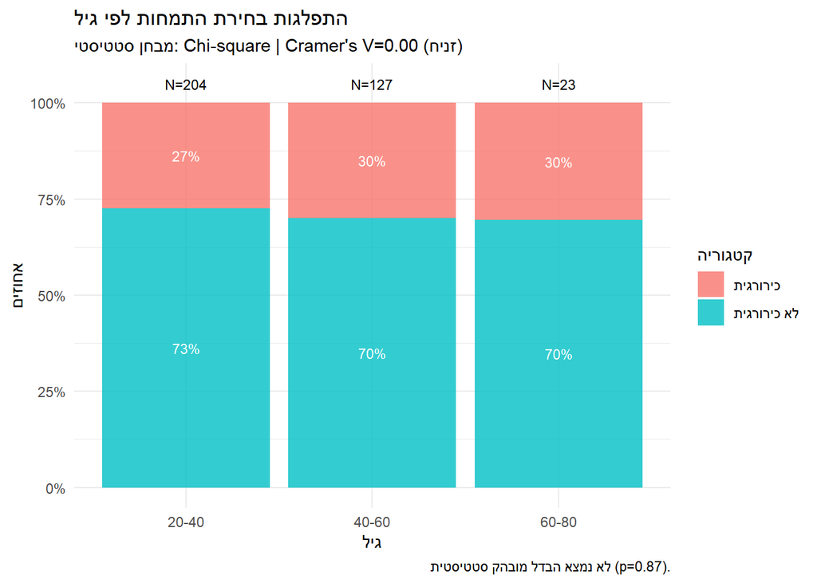

#### 2.1.1 גיל וקטגוריות התמחות ספציפיות

האם גיל המתמחה קשור לבחירת קטגוריית התמחות ספציפית (כירורגית, פנימית, משפחה, ילדים, וכו’)? **מבחן סטטיסטי:** Fisher’s Exact **מסקנה:** נמצא הבדל/קשר מובהק סטטיסטית (p<0.001). קיימת תלות מובהקת בין המשתנים.

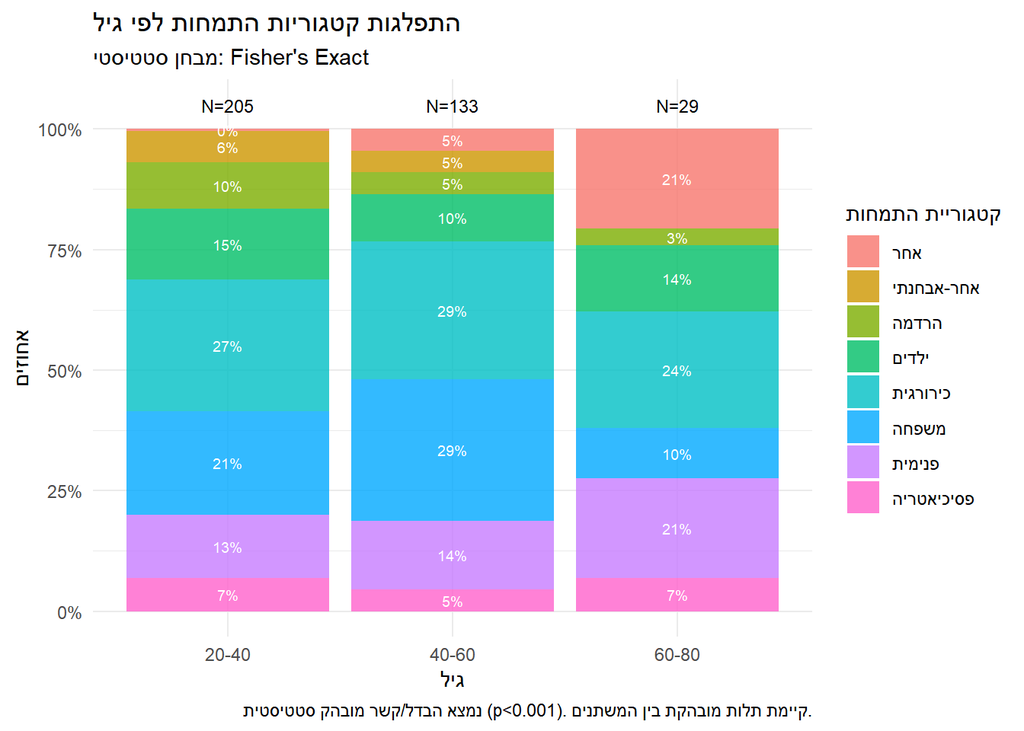

#### 2.1.2 Fisher test לכל קטגוריית התמחות בנפרד (גיל)

לכל קטגוריית התמחות, בוצע Fisher’s Exact test להשוואה בין גיל לבין “יש התמחות X” או “אחר”.

** ילדים : מבחן סטטיסטי:** Fisher’s Exact **מסקנה:** לא נמצא הבדל מובהק סטטיסטית (p=0.44). **P-value:** p=0.44

** משפחה : מבחן סטטיסטי:** Fisher’s Exact **מסקנה:** לא נמצא הבדל מובהק סטטיסטית (p=0.06). **P-value:** p=0.06

** כירורגית : מבחן סטטיסטי:** Fisher’s Exact **מסקנה:** לא נמצא הבדל מובהק סטטיסטית (p=0.90). **P-value:** p=0.90

** פנימית : מבחן סטטיסטי:** Fisher’s Exact **מסקנה:** לא נמצא הבדל מובהק סטטיסטית (p=0.51). **P-value:** p=0.51

** אחר-אבחנתי : מבחן סטטיסטי:** Fisher’s Exact **מסקנה:** לא נמצא הבדל מובהק סטטיסטית (p=0.47). **P-value:** p=0.47

** הרדמה : מבחן סטטיסטי:** Fisher’s Exact **מסקנה:** לא נמצא הבדל מובהק סטטיסטית (p=0.16). **P-value:** p=0.16

** פסיכיאטריה : מבחן סטטיסטי:** Fisher’s Exact **מסקנה:** לא נמצא הבדל מובהק סטטיסטית (p=0.65). **P-value:** p=0.65

### 2.2 מגדר וקטגוריית התמחות

האם קיימת זיקה בין מגדר לתחום ההתמחות?

עמודות: דמוגרפיה: מהו המגדר שלך?; נתוני הכשרה: קטגורית התמחות

**מבחן סטטיסטי:** Chi-square

**מסקנה:** נמצא הבדל/קשר מובהק סטטיסטית (p=0.002). קיימת תלות מובהקת בין המשתנים.

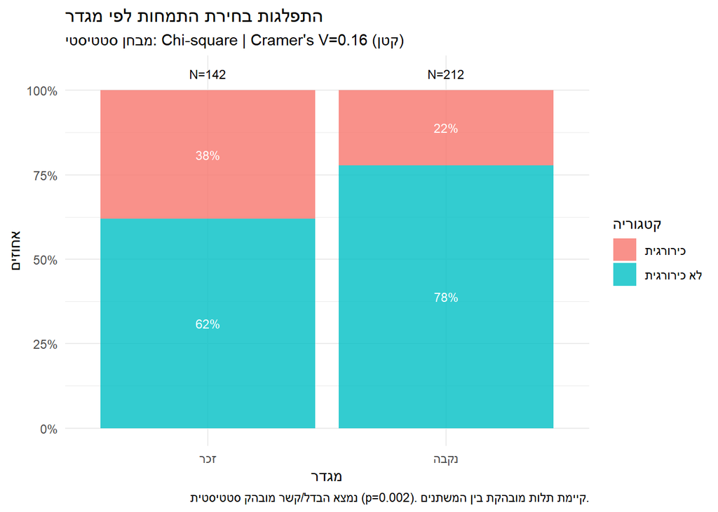

### 2.3 מצב משפחתי (הורות) ואיזון בית-עבודה

האם הורים מדווחים על איזון שונה מאשר לא-הורים?

עמודות: דמוגרפיה: הורה לילדים כעת?; דירוג הבחירה: איזון בית משפחה

**מבחן סטטיסטי:** t-test **מסקנה:** לא נמצא הבדל מובהק סטטיסטית (p=0.28).

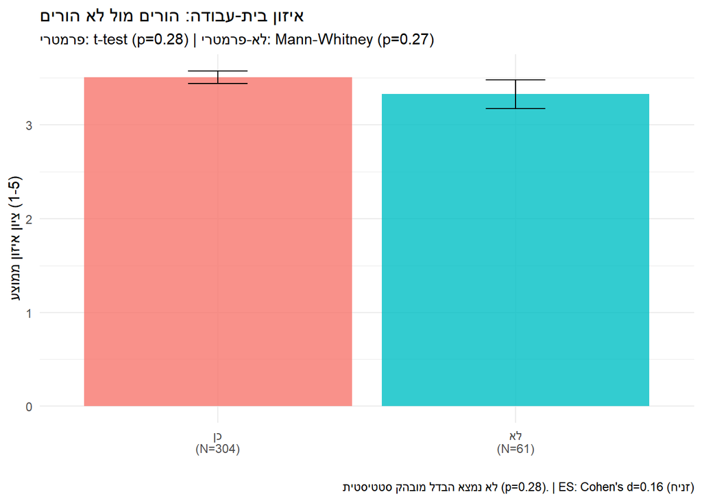

### 2.4 מדינת לימודים וקטגוריה

האם בוגרי חו”ל נמשכים לתחומים שונים מבוגרי הארץ?

עמודות: נתוני הכשרה: מדינת לימודים; נתוני הכשרה: קטגורית התמחות

**מבחן סטטיסטי:** Chi-square **מסקנה:** לא נמצא הבדל מובהק סטטיסטית (p=0.24).

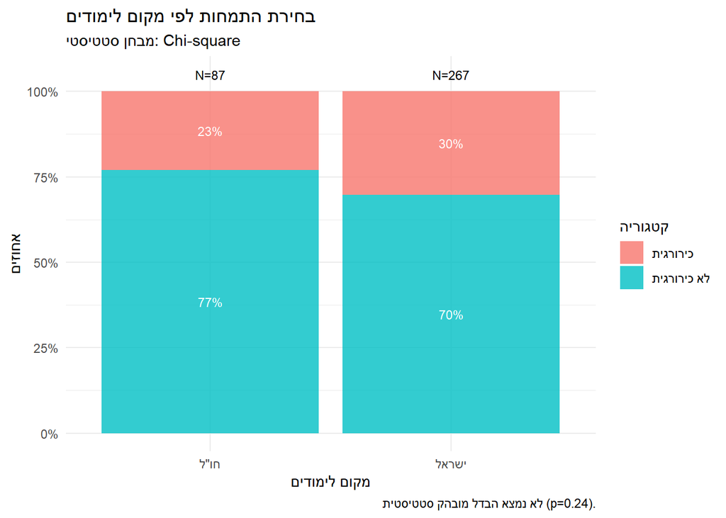

### 2.5 הורות במהלך ההתמחות

האם הורות במהלך ההתמחות קשורה לסוג ההתמחות שנבחרה?

עמודות: דמוגרפיה: הורה לילדים במהלך ההתמחות?; נתוני הכשרה: סוג ההתמחות

**מבחן סטטיסטי:** Chi-square **מסקנה:** נמצא הבדל/קשר מובהק סטטיסטית (p<0.001). קיימת תלות מובהקת בין המשתנים.

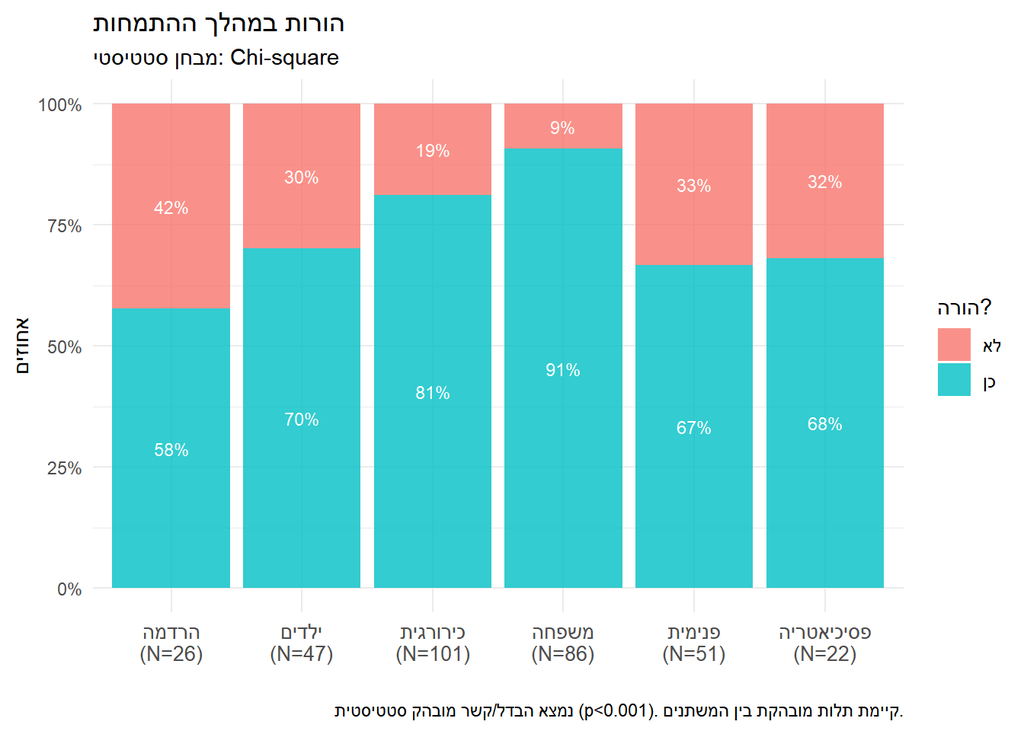

#### 2.5.1 הורות במהלך ההתמחות - נשים

```
## **מבחן סטטיסטי:** Fisher's Exact
##
## **מסקנה:** נמצא הבדל/קשר מובהק סטטיסטית (p<0.001). קיימת תלות מובהקת בין המשתנים.
```

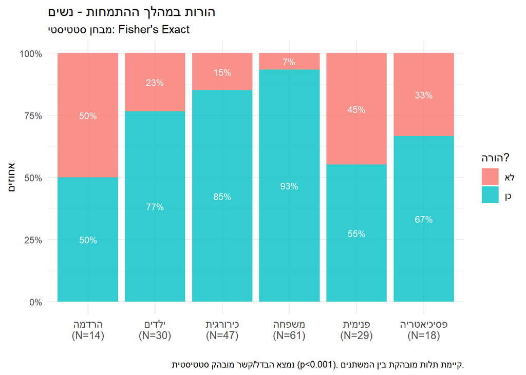

#### 2.5.2 הורות במהלך ההתמחות - גברים

```
## **מבחן סטטיסטי:** Fisher's Exact
##
## **מסקנה:** לא נמצא הבדל מובהק סטטיסטית (p=0.35).
```

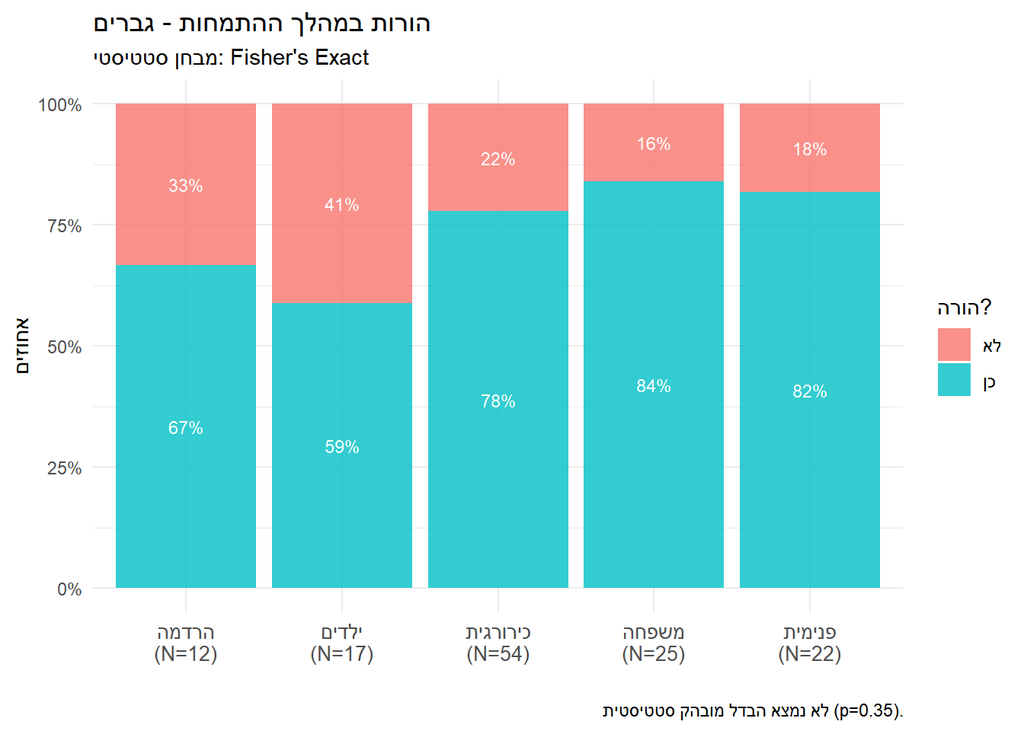

### 2.6 איזון בית-עבודה לפי גיל

עמודות: דמוגרפיה: מהו גילך?; דירוג הבחירה: איזון בית משפחה

האם מבוגרים יותר נמצאים בהתמחויות עם איזון טוב יותר? **מבחן סטטיסטי:** ANOVA **מסקנה:** לא נמצא הבדל מובהק סטטיסטית (p=0.48).

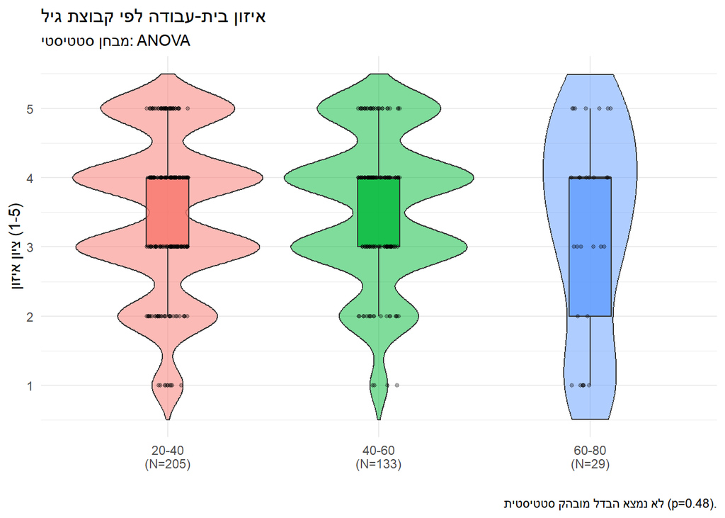

## 3 2. מניעים לבחירה ושביעות רצון עתידית

### 3.1 השפעת מנטורינג על שביעות רצון (ציפייה)

האם מי שבחר התמחות בגלל מנטורינג מרוצה יותר?

עמודות: העדפות הבחירה: מנטורינג; דירוג הבחירה: האם אני מרוצה

**מבחן סטטיסטי:** t-test **מסקנה:** לא נמצא הבדל מובהק סטטיסטית (p=0.23).

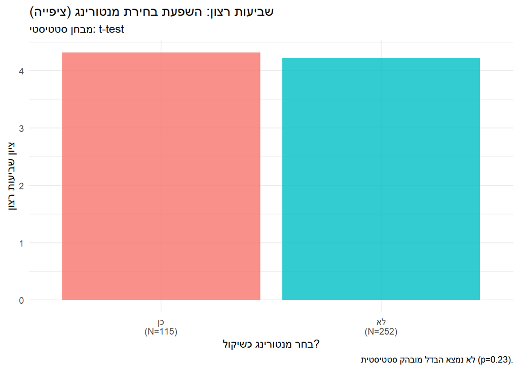

#### 3.1.1 טיצ’ינג בפועל ושביעות רצון

האם קיים קשר בין דירוג הטיצ’ינג (הוראה והדרכה בפועל) לשביעות הרצון?

עמודות: דירוג הבחירה: טיצ’ינג (הוראה והדרכה); דירוג הבחירה: האם אני מרוצה

```
## **מבחן סטטיסטי:** מתאם פירסון
##
## **מסקנה:** נמצא הבדל/קשר מובהק סטטיסטית (p<0.001). נמצא מתאם חיובי בעוצמה בינוני (r=0.37).
```

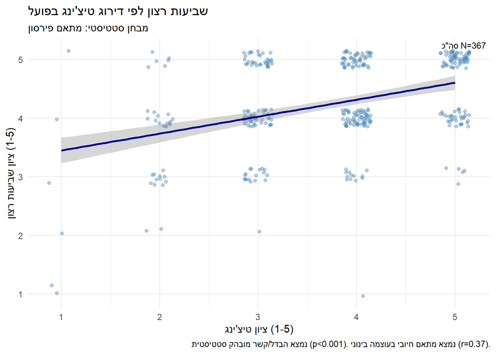

### 3.2 שביעות רצון בקרב מי שבחר מחקר

עמודות: העדפות הבחירה: שילוב מחקר; דירוג הבחירה: האם אני מרוצה

האם מי שציין מחקר כשיקול מדווח על שביעות רצון שונה? **מבחן סטטיסטי:** t-test **מסקנה:** לא נמצא הבדל מובהק סטטיסטית (p=0.22).

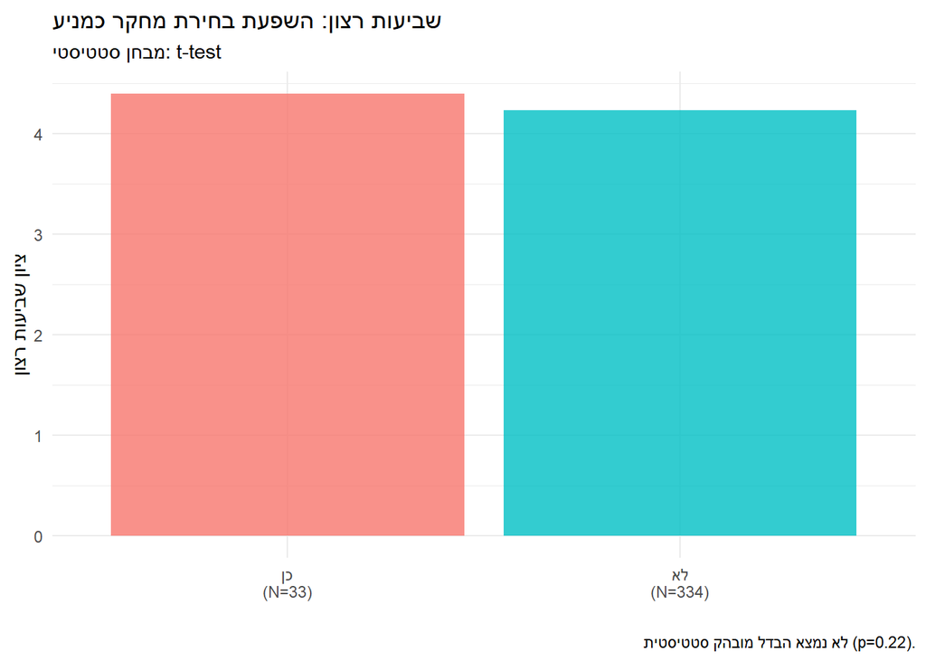

## 4 3. מאפייני התמחות והמלצה לחברים

### 4.1 באילו תחומים יש יותר תורנויות?

עמודות: נתוני הכשרה: כמות התורנויות; נתוני הכשרה: סוג ההתמחות

**מבחן סטטיסטי:** ANOVA **מסקנה:** נמצא הבדל/קשר מובהק סטטיסטית (p<0.001). הערכים הגבוהים ביותר נצפו בקבוצה: ‘ילדים’.

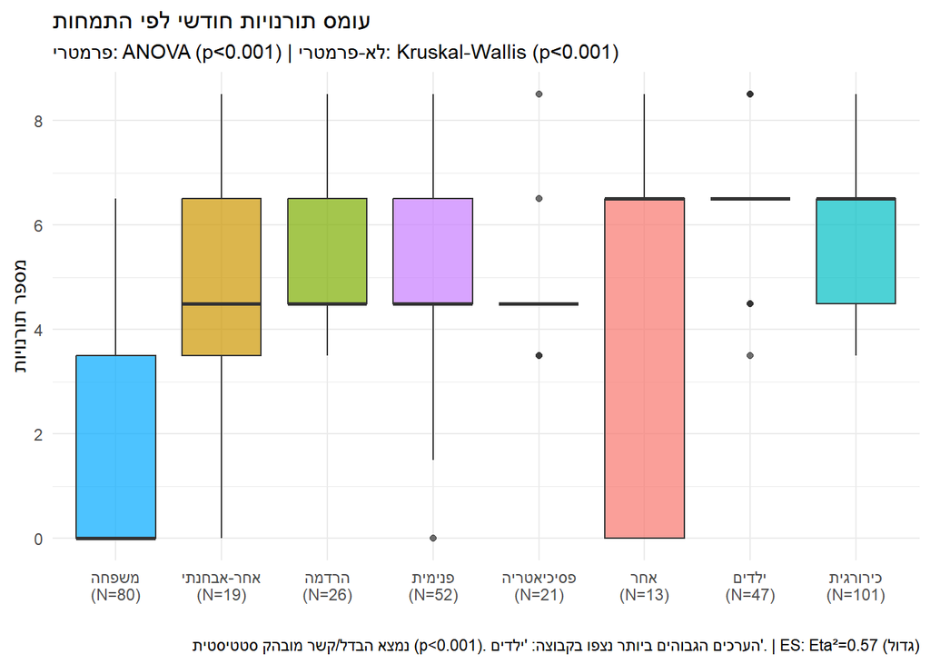

### 4.2 דירוג יחסי צוות לפי התמחות

עמודות: דירוג הבחירה: יחס קולגות; נתוני הכשרה: סוג ההתמחות

היכן הדירוג של יחסי צוות גבוה יותר? **מבחן סטטיסטי:** ANOVA **מסקנה:** נמצא הבדל/קשר מובהק סטטיסטית (p<0.001). הערכים הגבוהים ביותר נצפו בקבוצה: ‘פסיכיאטריה’.

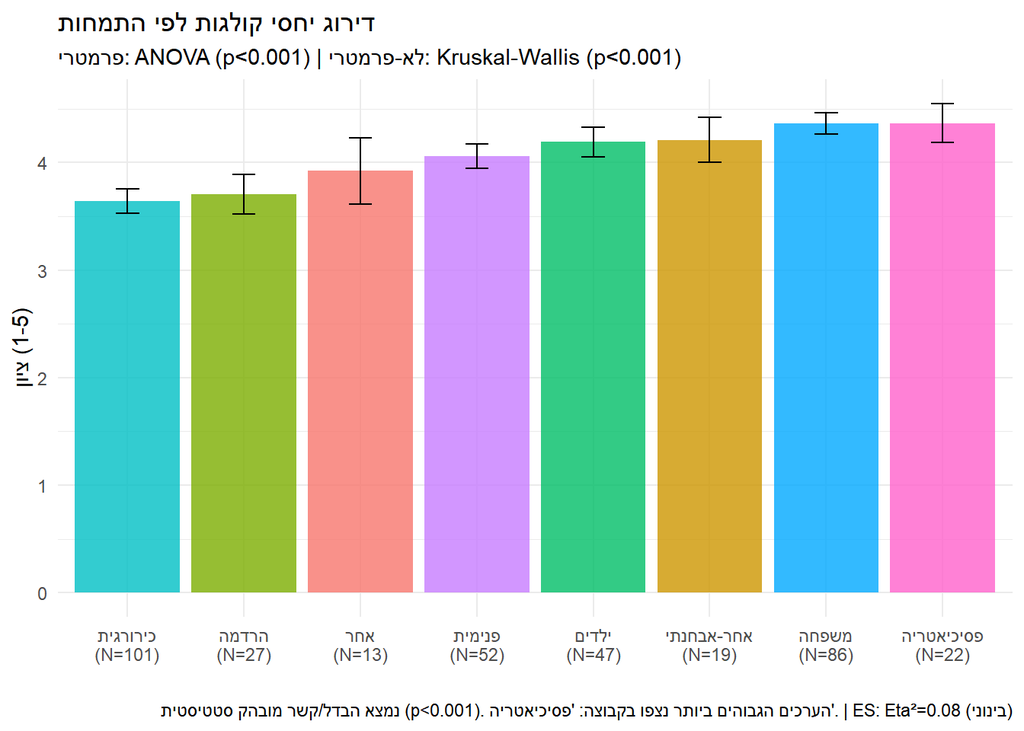

### 4.3 עומס בירוקרטי וחרטה על הבחירה

עמודות: דירוג הבחירה: בירוקרטיה; דירוג הבחירה: האם היית בוחר בהתמחות אחרת

האם עומס בירוקרטי קשור להחלטה האם לבחור שוב באותה התמחות? **מבחן סטטיסטי:** t-test **מסקנה:** נמצא הבדל/קשר מובהק סטטיסטית (p=0.006). הערכים הגבוהים ביותר נצפו בקבוצה: ‘מתחרט/ת’.

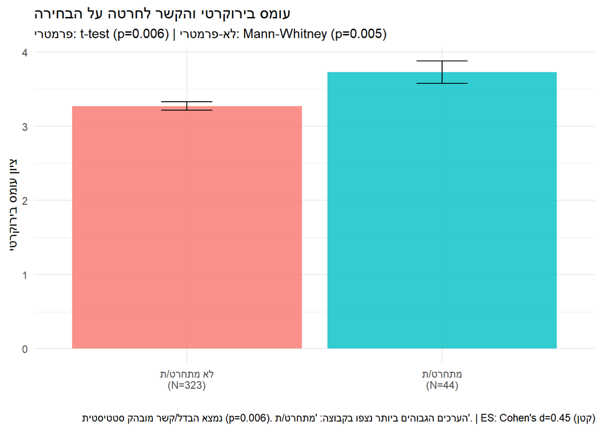

### 4.4 שכר ושביעות רצון - שכר בפועל

עמודות: נתוני הכשרה: רמת ההשתכרות בפועל; דירוג הבחירה: האם אני מרוצה

האם גובה השכר בפועל קשור לשביעות הרצון הכללית? **מבחן סטטיסטי:** ANOVA **מסקנה:** לא נמצא הבדל מובהק סטטיסטית (p=0.57).

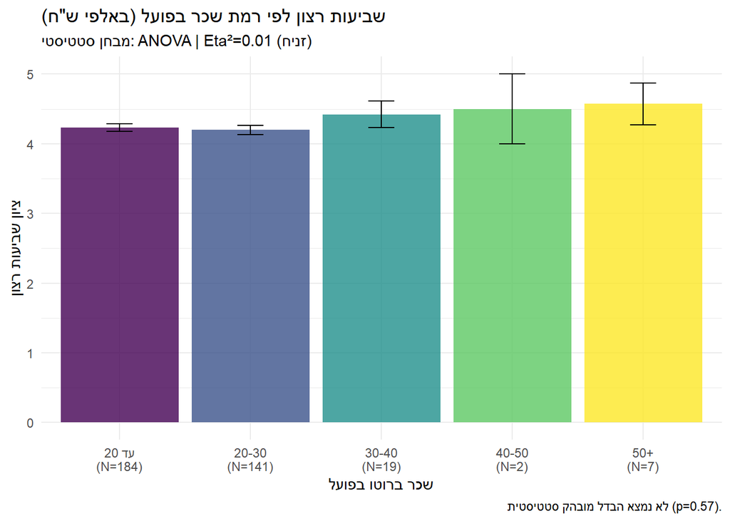

### 4.5 מנבאי המלצה לחברים (רגרסיה)

אילו פרמטרים מנבאים בצורה הטובה ביותר אם מתמחה ימליץ לחבר? (יחס סיכויים > 1 מעיד על השפעה חיובית).

**מסקנה:** מודל מנבא: שביעות רצון היא המשתנה המשפיע ביותר.

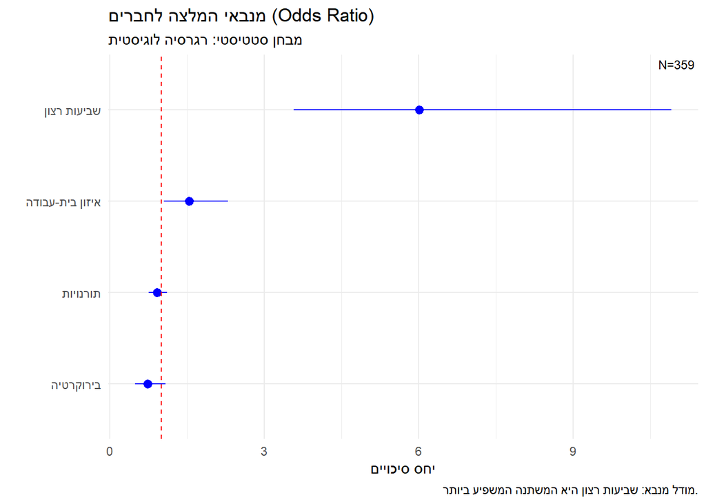

## 5 4. קטגוריות התמחות - חוויות

### 5.1 כירורגיה: עומס פיזי (עבודה ידנית)

עמודות: דירוג הבחירה: עבודה מנואלית; נתוני הכשרה: קטגורית התמחות

**מבחן סטטיסטי:** t-test **מסקנה:** נמצא הבדל/קשר מובהק סטטיסטית (p<0.001). הערכים הגבוהים ביותר נצפו בקבוצה: ‘כירורגית’.

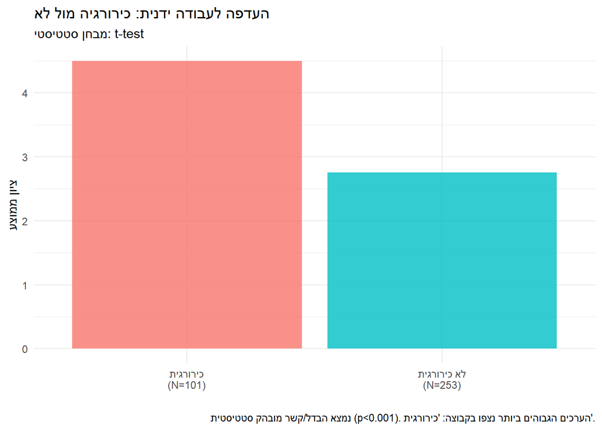

### 5.2 כירורגיה: סטרס (רוגע)

עמודות: דירוג הבחירה: עבודה בתנאי לחץ; נתוני הכשרה: קטגורית התמחות

**מבחן סטטיסטי:** t-test **מסקנה:** נמצא הבדל/קשר מובהק סטטיסטית (p<0.001). הערכים הגבוהים ביותר נצפו בקבוצה: ‘לא כירורגית’.

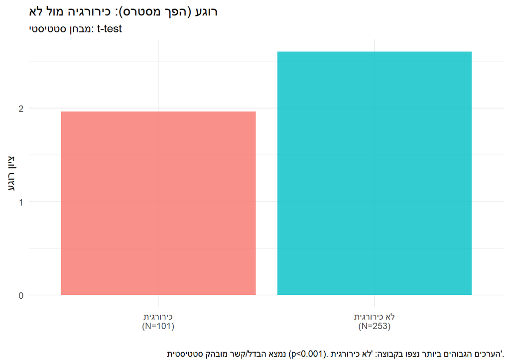

### 5.3 פנימית: משמעות וסיפוק

עמודות: דירוג הבחירה: משמעות וסיפוק; נתוני הכשרה: סוג ההתמחות (פנימית)

**מבחן סטטיסטי:** t-test **מסקנה:** לא נמצא הבדל מובהק סטטיסטית (p=0.58).

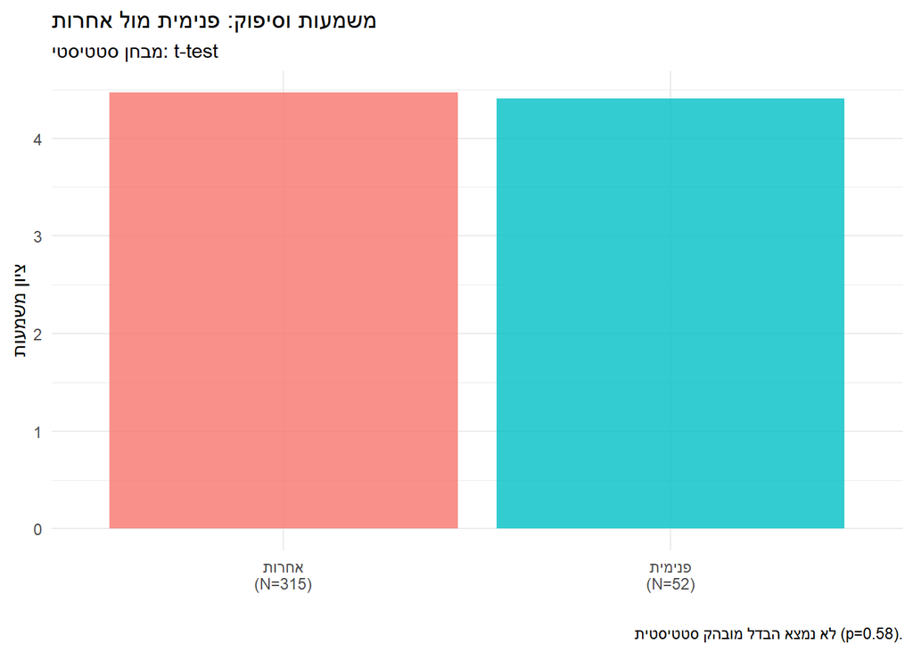

### 5.4 פנימית: עומס בירוקרטי

עמודות: דירוג הבחירה: בירוקרטיה; נתוני הכשרה: סוג ההתמחות (פנימית)

**מבחן סטטיסטי:** t-test **מסקנה:** לא נמצא הבדל מובהק סטטיסטית (p=0.08).

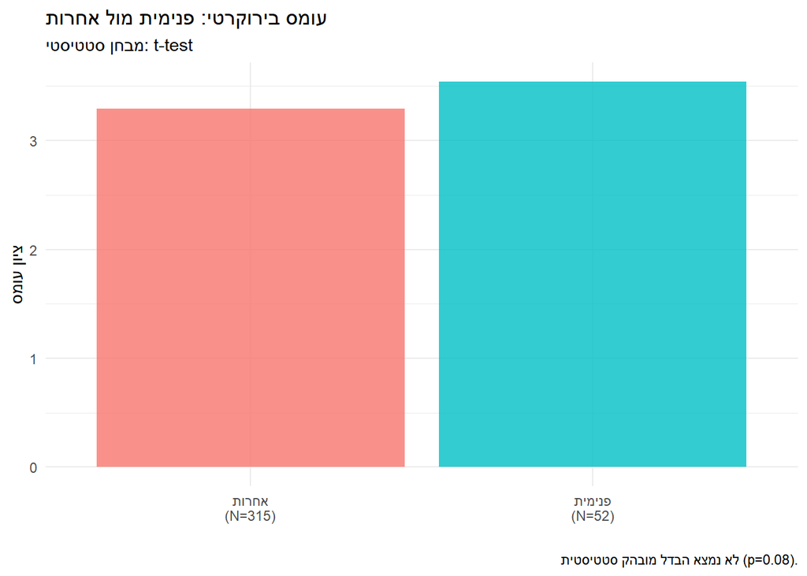

### 5.5 משפחה (קהילה): איזון בית-עבודה

עמודות: דירוג הבחירה: איזון בית משפחה; נתוני הכשרה: סוג ההתמחות (משפחה)

**מבחן סטטיסטי:** t-test **מסקנה:** נמצא הבדל/קשר מובהק סטטיסטית (p<0.001). הערכים הגבוהים ביותר נצפו בקבוצה: ‘משפחה’.

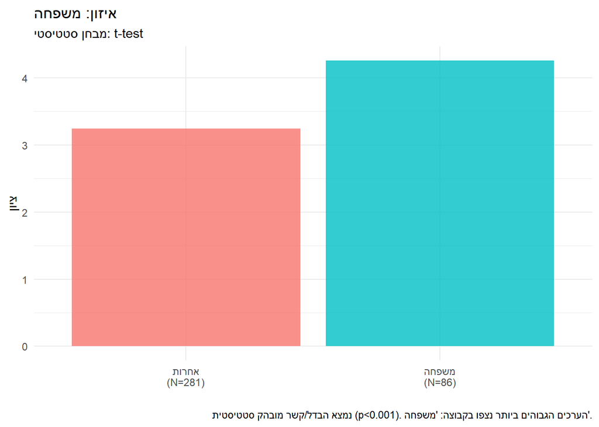

### 5.6 משפחה: אפשרות למחקר

עמודות: דירוג הבחירה: אפשרות להתקדם במחקר; נתוני הכשרה: סוג ההתמחות (משפחה)

**מבחן סטטיסטי:** t-test **מסקנה:** נמצא הבדל/קשר מובהק סטטיסטית (p<0.001). הערכים הגבוהים ביותר נצפו בקבוצה: ‘אחרות’.

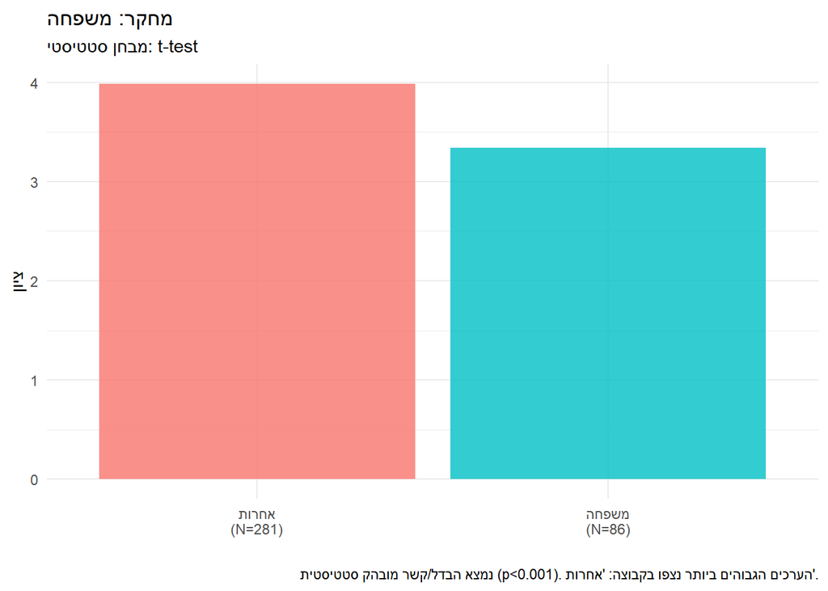

## 6 5. קריירה עתידית - בחירת התמחות

### 6.1 חשיבות Fellowship בחו”ל

עמודות: דירוג הבחירה: Fellowship בחו”ל; נתוני הכשרה: קטגורית התמחות

מי שסימן שחשוב לו פלושיפ, לאן פנה? **מבחן סטטיסטי:** t-test **מסקנה:** נמצא הבדל/קשר מובהק סטטיסטית (p<0.001). הערכים הגבוהים ביותר נצפו בקבוצה: ‘כירורגית’.

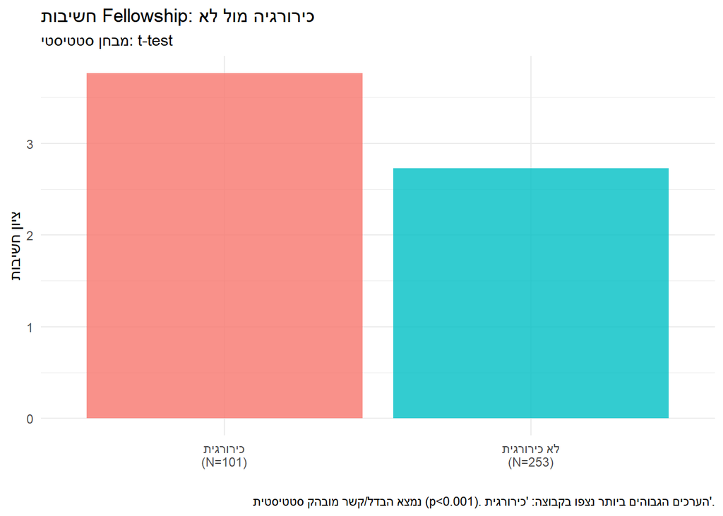

### 6.2 חשיבות עבודה בקהילה

עמודות: דירוג הבחירה: עבודה בקהילה; נתוני הכשרה: קטגורית התמחות

מי שראה חשיבות בעבודה בקהילה, לאן הלך? **מבחן סטטיסטי:** t-test **מסקנה:** נמצא הבדל/קשר מובהק סטטיסטית (p=0.05). הערכים הגבוהים ביותר נצפו בקבוצה: ‘כירורגית’.

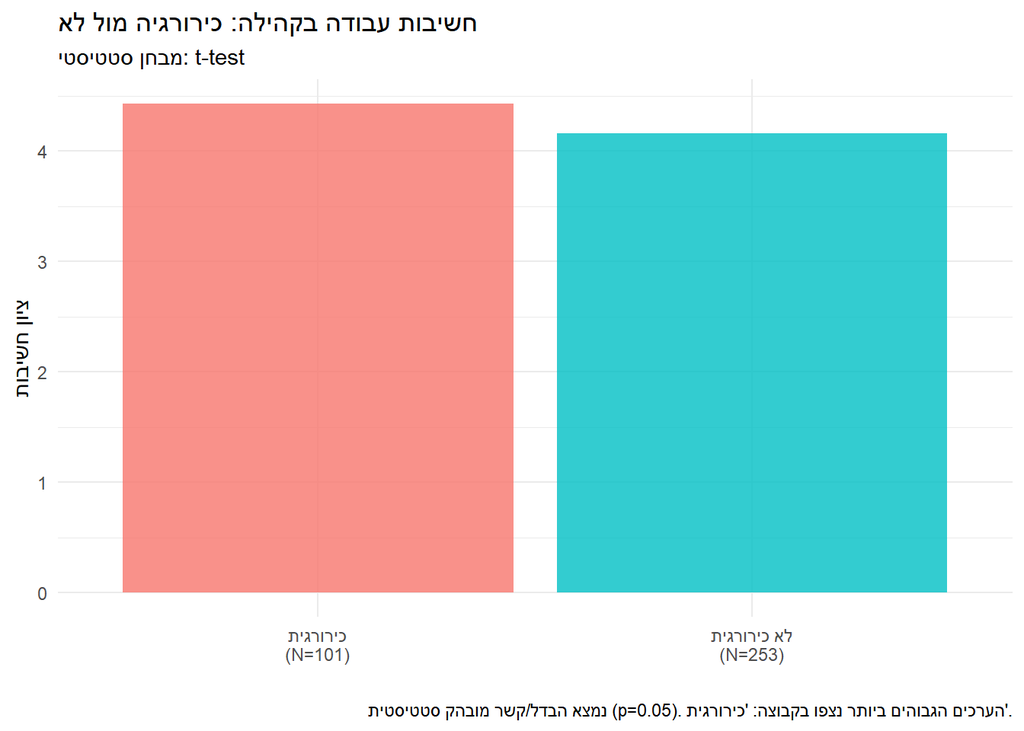

### 6.3 חשיבות עבודה פרטית

עמודות: דירוג הבחירה: עבודה פרטית; נתוני הכשרה: קטגורית התמחות

מי שחשובה לו עבודה פרטית, לאן פנה? **מבחן סטטיסטי:** t-test **מסקנה:** נמצא הבדל/קשר מובהק סטטיסטית (p<0.001). הערכים הגבוהים ביותר נצפו בקבוצה: ‘כירורגית’.

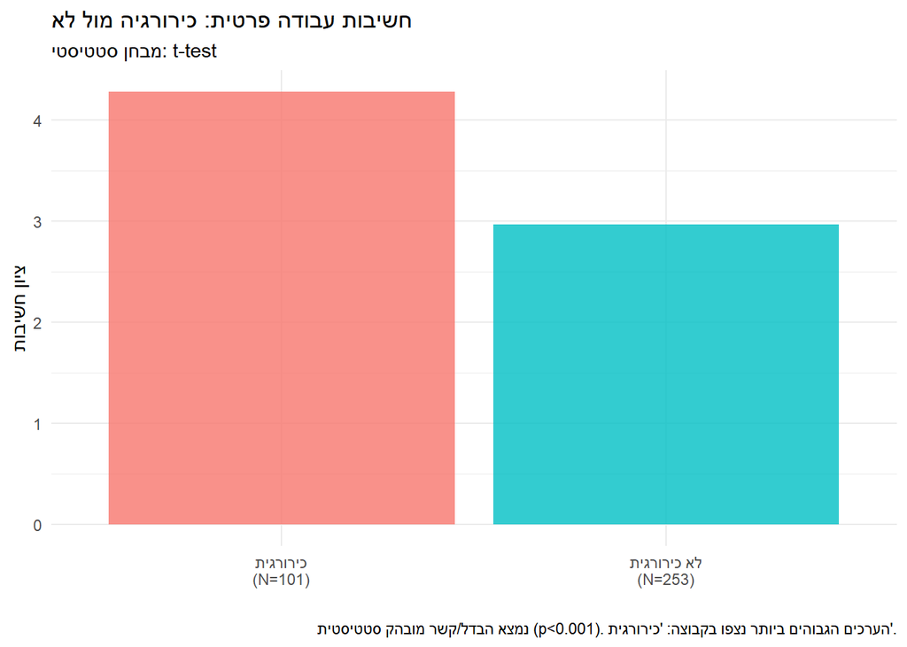

### 6.4 לאן פנו מי שסימנו מחקר כחשוב? (ציפייה)

עמודות: העדפות הבחירה: שילוב מחקר; נתוני הכשרה: סוג ההתמחות

גרף זה מציג את ההתפלגות להתמחויות בקרב אלו שסימנו “מחקר” כשיקול לבחירה. **מבחן סטטיסטי:** תיאור תפלגות

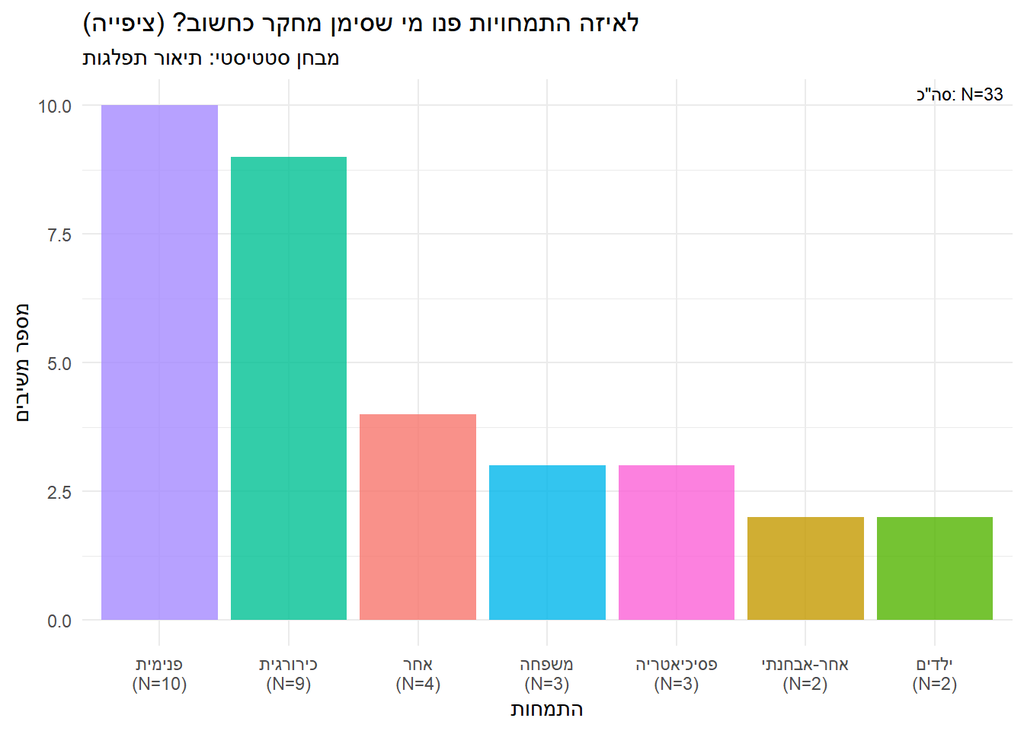

#### 6.4.1 אפשרות להתקדם במחקר בפועל לפי התמחות

עמודות: דירוג הבחירה: אפשרות להתקדם במחקר; נתוני הכשרה: סוג ההתמחות

```
## **מבחן סטטיסטי:** ANOVA
##
## **מסקנה:** נמצא הבדל/קשר מובהק סטטיסטית (p<0.001). הערכים הגבוהים ביותר נצפו בקבוצה: 'כירורגית'.
```

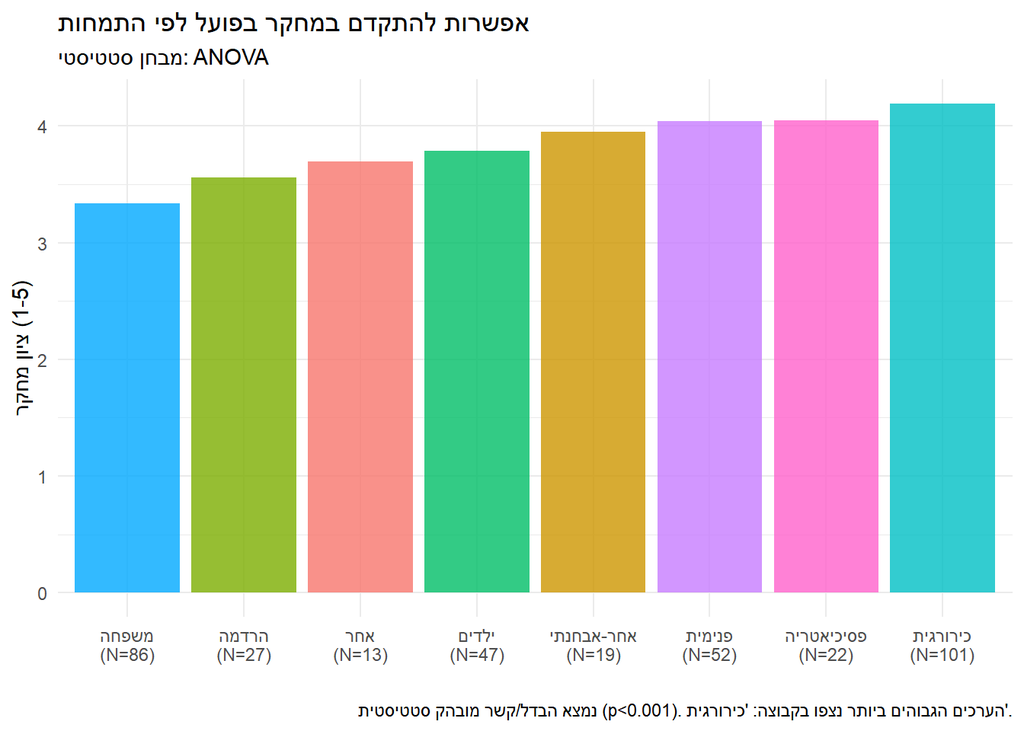

#### 6.4.2 השוואה: ציפייה מול מציאות במחקר

מי שבחר מחקר כשיקול - האם מדרג גבוה יותר את אפשרויות המחקר בפועל?

```
## **מבחן סטטיסטי:** t-test
##
## **מסקנה:** נמצא הבדל/קשר מובהק סטטיסטית (p<0.001). הערכים הגבוהים ביותר נצפו בקבוצה: 'כן'.
```

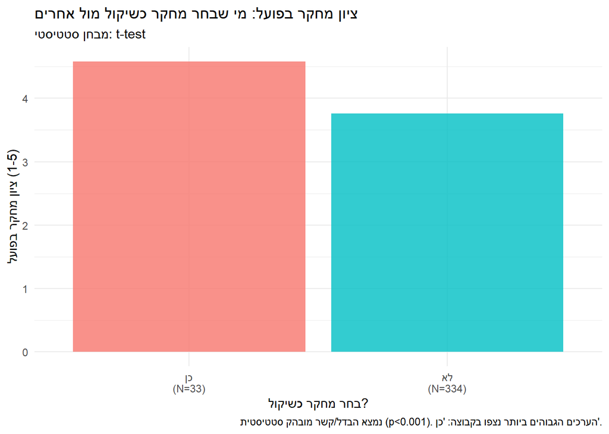

### 6.5 התפלגות מקום עבודה בפועל

עמודות: עיסוק נוכחי: היכן את/ה עובד/ת?

גרף זה מציג את היכן עובדים המתמחים בפועל. **מבחן סטטיסטי:** תיאור תפלגות

[figure not shown]

## 7 6. שביעות רצון - בחירה מחדש (Switchers)

### 7.1 שביעות רצון של מחליפים

עמודות: נתוני הכשרה: האם החלפת התמחות; דירוג הבחירה: האם אני מרוצה

האם מי שהחליף התמחות מרוצה יותר או פחות? **מבחן סטטיסטי:** t-test **מסקנה:** לא נמצא הבדל מובהק סטטיסטית (p=0.90).

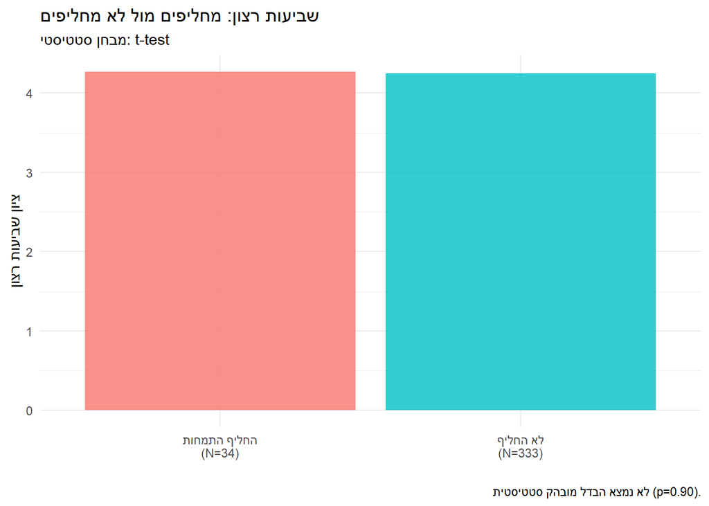

### 7.2 גורמים: בירוקרטיה אצל מחליפים

עמודות: נתוני הכשרה: האם החלפת התמחות; דירוג הבחירה: בירוקרטיה

**מבחן סטטיסטי:** t-test **מסקנה:** לא נמצא הבדל מובהק סטטיסטית (p=0.09). נצפתה מגמה (p<0.1)

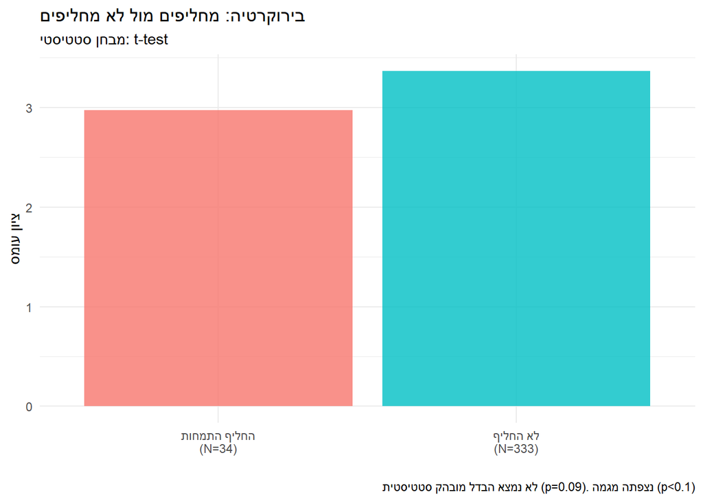